# Deconvolution of Specific Inherent Optical Properties (SIOPs)

## Approach

Assume there are 4 non-water constituents: phytoplankton $(\phi)$, minerals $(m)$. detritus $(d)$ and coloured dissolved organic material $(g)$ and that:

$a(\lambda) = a_\phi(\lambda)\phi + a_m(\lambda)m + a_d(\lambda)d + a_g(\lambda)g + a_w(\lambda)$

$b_b(\lambda) = b_{b\phi}(\lambda)\phi + b_{bm}(\lambda)m + b_{bd}(\lambda)d + b_{bw}(\lambda)$

Where:

$\left[\frac{b_b}{a}\right](\lambda) = \frac{b_{b\phi}(\lambda).\phi + b_{bm}(\lambda).m + b_{bd}(\lambda).d + b_{bw}(\lambda)}{a_\phi(\lambda).\phi + a_m(\lambda) + a_d(\lambda).g + a_w(\lambda)}$

Factorised and rearranged ( $\lambda$ is dropeed for brievity)

$A(\lambda) = \left(a_\phi\frac{b_b}{a} - b_\phi \right)\phi + \left(a_m\frac{b_b}{a} - b_m \right)m + \left(a_d\frac{b_b}{a} - b_d \right)d + \left(a_g\frac{b_b}{a} - b_g \right)g$

And

$b(\lambda) = -\left(a_w\frac{b_b}{a} - b_w \right)$

The general model for n constituents

$0 = \sum\limits_{i=1}^n\left[a_i(\lambda)\left[ \frac{b_b}{a}\right](\lambda) - b_{bi}(\lambda) \right].x_i + a_w(\lambda)\left[\frac{b_b}{a}\right](\lambda) - b_{bw} $

Put in matrix format

$A_{\lambda_m,n} = \begin{pmatrix} p_{\lambda_1,\phi} & p_{\lambda_1,m} & p_{\lambda_1,d} & p_{\lambda_1,g} \\ p_{\lambda_2,\phi} & p_{\lambda_2,m} & p_{\lambda_2,d} & p_{\lambda_2,g} \\ \vdots & \vdots & \vdots & \vdots \\ p_{\lambda_m,\phi} & p_{\lambda_m,m} & p_{\lambda_m,d} & p_{\lambda_m,g} \end{pmatrix}$ $x = \begin{pmatrix} \phi \\ m \\ d \\ g \\ \end{pmatrix} $ $ b_{\lambda_m} = \begin{pmatrix} q_{\lambda_1, k} \\ q_{\lambda_2, k} \\ \vdots \\ q_{\lambda_m, k} \end{pmatrix} $

Where

$p~$ is $~~a_i(\lambda)\left[ \frac{b_b}{a}\right](\lambda) - b_{bi}(\lambda)$

$q~$ is $~~ -a_w(\lambda)\left[\frac{b_b}{a}\right](\lambda) - b_{bw} $

The solution of $x$ is the solution to the Matrix equation

$Ax=b$

## Bootstrap method

The boot strap method is a technique that can increase empirical confidence of estimated parameters. The method works by simulating noise inherent in the data which has the effect of synthentically increasing the sample size of the training set of data.

One variation of the boot strap method is to define a training set of data and a validation set of data. The method makes an estimate of the noise and assumes that it is small with respect to the parameters and have zero mean.

$y = f(x) + \epsilon$

Where $\epsilon$ is noise with an empirical distribution. A basic summary of the process is as follows.

- For a training set of measurements ${x_i}$ estimate a noise level.
- Resample the measurements by generating a new set of measurements ${x_i + \epsilon_i}$
- Invert the model of parameters of interest
- Cross-validate the training set against the validation set of data
- Repeat this procoess for a new choice of noise until there is no improvement in the prediction

The following sections investigates the suitability of the bootstrap to deconvolving in-water constituents from absorption and scattering measurements by first testing the affectiveness of the method on a synthetic dataset followed by testing the method on measurements made in the Ligurian sea and validated against laboratory measurements.

# Sections

Deconvolution of Specific Inherent Optical Properties

- Bootstrap Method

Test

- Test Dataset
- Model Implementation
- Sensitivity Tests
  - Test 1
  - Test 2
  - Test 3
  - Test 4
    - Test 4a
  - Test 5
  - Test 6

Inversion of ACS

- SIOPs from Ligurian Sea
- Characterising the noise
- Noise Distribution

Optical deconvolution of ACS measurements

- Data file
- Modelling the noise
- Assumptions
- Method
- Results

Conclusions

# Test

Firstly, to test the method a purely synthetic data set was used to test he peformance and sensitivity of the model. The model was coded using python2.7 and shown below.

## Test Dataset

```python
import numpy as np
import scipy
from scipy.sparse import linalg

wavelength  = np.asarray([412, 440, 488, 510, 532, 555, 650, 676, 715])
a_phi = np.asarray([0.0366, 0.0434, 0.0304, 0.0211, 0.0145, 0.0098, 0.0094, 0.0244, 0.0015])
a_d = np.asarray([0.0071, 0.0055, 0.0031, 0.0024, 0.0017, 0.0014, 0.0012, 0.0017, 0.0008])
a_m = np.asarray([0.0672, 0.0468, 0.0303, 0.0230, 0.0178, 0.0132, 0.0082, 0.0074, 0.0069])
a_g = np.asarray([1.6619, 1.0000, 0.4540, 0.3253, 0.2503, 0.1745, 0.0463, 0.0208, 0.0000])
bb_phi = np.asarray([0.00194, 0.00170, 0.00183, 0.00199, 0.00178, 0.00169, 0.00157, 0.00147, 0.00144])
bb_m = np.asarray([0.02075, 0.01880, 0.01854, 0.01898, 0.01710, 0.01639, 0.01602, 0.01444, 0.01320])
bb_g = np.asarray([0, 0, 0, 0, 0, 0, 0, 0, 0])
bb_d = np.asarray([0, 0, 0, 0, 0, 0, 0, 0, 0])
a_w = np.asarray([0.00469, 0.00635, 0.01454, 0.0325, 0.0442, 0.0592, 0.34, 0.4546, 1.029])
bb_w = np.asarray([0.00333, 0.00245, 0.00158, 0.0013, 0.00109, 0.000925, 0.0005, 0.00037, 0.000325])
```

## Model implementation

Below the deconvolution via bootstrap technique code in Python. The function defined is:

```
run_bootstrap(a_phi, a_m, a_d, a_g, a_w, bb_phi, bb_m, bb_d, bb_g, bb_w,
            phi=1, m=1, d=1, g=1, num_bootstraps=1, noise=0)
```

Where:

- a_phi is $a_\phi$: absorption due to phytoplankton
- a_m is $a_m$: absorption due to suspended minerals
- a_d is $a_d$: absorption due to organic detritus
- a_g is $a_g$: absorption due to gelbstoff
- a_w is $a_w$: absorption of pure sea water
- bb_phi is $b_{b\phi}$: backscatter due to phytoplankton
- bb_m is $b_{bm}$: backscatter due to suspended minerals
- bb_d is $b_{bd}$: backscatter due to organic detritus
- bb_g is $b_{bg}$: backscatter due to gelbstoff
- bb_w is $b_{bw}$: backscatter due to pure sea water
- phi is $\phi$: concentration of phytoplankton
- m is $m$: relative concentration of minerals with respect the SIOP
- d is $d$: relative concentration of detritus with respect to the SIOP
- g is $g$: relative concentration of gelbstoff with respect to the SIOP
- num_bootstraps: is the number replication of in input data
- noise is percentage: from mean of 1 standard deviation random noise

Here `(`$\phi$`, m, d , g)` are 'helper parameters' which make it possible to artificially scale the inputs. In practice these should be left at 1.0 (i.e. no scaling) as the scaling is what the model is trying to invert.

```python
def run_bootstrap(a_phi, a_m, a_d, a_g, a_w, bb_phi, bb_m, bb_d, bb_g, bb_w, phi=1, m=1, d=1, g=1, num_bootstraps=1, noise=0):
    Aa = np.zeros((wavelength.shape[0], 4))
    Aa[:, 0] = a_phi.T #* phi
    Aa[:, 1] = a_m.T #* m
    Aa[:, 2] = a_d.T #* d
    Aa[:, 3] = a_g.T #* g

    Ab = np.zeros((wavelength.shape[0], 4))
    Ab[:, 0] = bb_phi.T #* phi
    Ab[:, 1] = bb_m.T #* m
    Ab[:, 2] = bb_d.T #* d
    Ab[:, 3] = bb_g.T #* g

    A = np.zeros((Aa.shape[0], Aa.shape[1]))

    a = a_phi + a_d + a_m + a_g + a_w
    bb = bb_phi + bb_m + bb_g + bb_w
    bb_over_a = bb / a

    scale = np.array([phi, m, d, g])

    for i_iter in range(Aa.shape[1]):
        A[:, i_iter] = (Aa[:, i_iter] * (bb_over_a[:]) - Ab[:, i_iter]) * scale[i_iter]


    b = (scipy.squeeze(a_w.T) * bb_over_a - scipy.squeeze(bb_w.T)) * -1

    #--------------------------------------------------#
    # Now we replicate the matricies and add the noise
    #--------------------------------------------------#
    A = scipy.tile(A, (num_bootstraps, 1))
    b = scipy.tile(b, (num_bootstraps))

    #noise_a = (scipy.random.randn(np.int(A.shape[0]), np.int(A.shape[1])) * noise) + 1
    #noise_b = (scipy.random.randn(np.int(b.shape[0])) * noise) + 1
    noise_a = scipy.random.uniform(low=(1 - noise), high=(1 + noise), size=A.shape)
    noise_b = scipy.random.uniform(low=(1 - noise), high=(1 + noise), size=b.shape)

    A = A + noise_a
    b = b + noise_b

    x = scipy.sparse.linalg.lsqr(A, b.T)

    return 1.0 / x[0] , x[1]
```

# Sensitivity Tests

## Test 1

Here the test is run with 0% noise and no replication of the data. The expect return values are 1.0 for all values as the model should just return the concentration of the inputs with respect to the inputs. There is no artificial scalling of the parameters

```python
x = run_bootstrap(a_phi, a_m, a_d, a_g, a_w, bb_phi, bb_m, bb_d, bb_g, bb_w)
for i in x[0]:
    print(i)
```

```
1.0000000025
1.00000002563
1.00000000045
1.00000002805
```

## Test 2

Test 1 is repeated with 10000 bootstraps and 0% noise. The expected return values are also expected to be 1.0 for all values as no noise has been added. The model is over determined, however all new bootstraps are copies of the inputs and therefore linearly dependent. This test is primarily to test the software and the hardware memory requirements.

```python
scale_vals = np.asarray([1, 1, 1, 1])
num_bootstraps = 10000
noise = 0.0
param_str_list = ['p', 'm', 'd', 'g']
phi = scale_vals[0]
m = scale_vals[1]
d = scale_vals[2]
g = scale_vals[3]

x = run_bootstrap(a_phi, a_m, a_d, a_g, a_w, bb_phi, bb_m, bb_d, bb_g, bb_w,
                  phi=phi, m=m, d=d, g=g,
                  num_bootstraps=num_bootstraps, noise=noise)

residual = ((x[0] - scale_vals) / x[0]) * 100

print('=============================')
print('P :: value     :: residual %')
print('-----------------------------')
for i_iter, i in enumerate(x[0]):
    print('{0} :: {1:4f}  :: {2:4f} %' ).format(param_str_list[i_iter], i, residual[i_iter])
    #print(i)
print('=============================')
```

```
=============================
P :: value     :: residual %
-----------------------------
p :: 1.000000  :: -0.000000 %
m :: 1.000000  :: 0.000000 %
d :: 1.000000  :: -0.000000 %
g :: 1.000000  :: 0.000000 %
=============================
```

## Test 3

```python
scale_vals = np.asarray([1, 1, 1, 1])
num_bootstraps = 100000
noise = 0.01
param_str_list = ['p', 'm', 'd', 'g']
phi = scale_vals[0]
m = scale_vals[1]
d = scale_vals[2]
g = scale_vals[3]

x = run_bootstrap(a_phi, a_m, a_d, a_g, a_w, bb_phi, bb_m, bb_d, bb_g, bb_w,
                  phi=phi, m=m, d=d, g=g,
                  num_bootstraps=num_bootstraps, noise=noise)

residual = ((x[0] - scale_vals) / x[0]) * 100

print('=============================')
print('P :: value     :: residual %')
print('-----------------------------')
for i_iter, i in enumerate(x[0]):
    print('{0} :: {1:4f}  :: {2:4f} %' ).format(param_str_list[i_iter], i, residual[i_iter])
    #print(i)
print('=============================')
```

```
=============================
P :: value     :: residual %
-----------------------------
p :: 0.966417  :: -3.474999 %
m :: 1.004118  :: 0.410069 %
d :: 1.715128  :: 41.695303 %
g :: 0.999619  :: -0.038073 %
=============================
```

## Test 4

We hold the number of bootstraps constant and slowly increase the level of the noise.

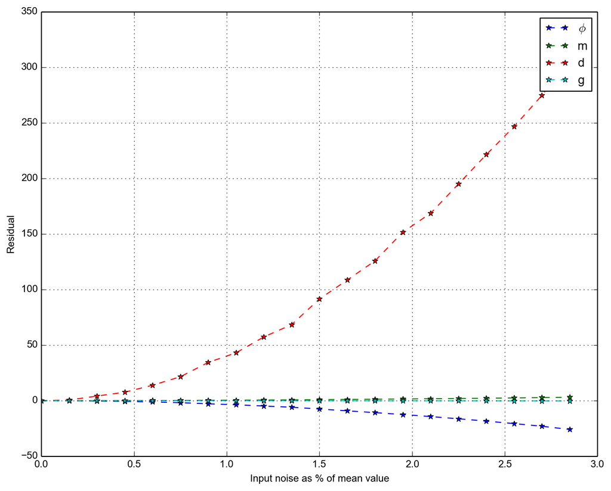

```python
%matplotlib inline
pylab.rcParams['figure.figsize'] = (10.0, 8.0)
matplotlib.rcParams['savefig.dpi'] = 200
scale_vals = np.asarray([1, 1, 1, 1])
num_bootstraps = 100000
min_noise = 0
max_noise = 0.03
noise_steps = 0.0015

phi = scale_vals[0]
m = scale_vals[1]
d = scale_vals[2]
g = scale_vals[3]

x_list = []
residual_list = []
noise_list = []

for noise in np.arange(min_noise, max_noise, noise_steps):
    noise_list.append(noise)
    x = run_bootstrap(a_phi, a_m, a_d, a_g, a_w, bb_phi, bb_m, bb_d, bb_g, bb_w,
                      phi=phi, m=m, d=d, g=g,
                      num_bootstraps=num_bootstraps, noise=noise)
    residual = (((x[0] - scale_vals) / x[0]) * 100)
    x_list.append(x[0])
    residual_list.append(residual)

noise_x = np.asarray(noise_list) * 100
res_y = np.asarray(residual_list)
p1 = pylab.plot(noise_x, res_y[:,0],'--*')
p2 = pylab.plot(noise_x, res_y[:,1],'--*')
p3 = pylab.plot(noise_x, res_y[:,2],'--*')
p4 = pylab.plot(noise_x, res_y[:,3],'--*')
p = Rectangle((0, 0), 1, 1, fc="r")
pylab.legend(['$\phi$', 'm', 'd', 'g'])
pylab.ylabel('Residual')
pylab.xlabel('Input noise as % of mean value')
pylab.grid()
#pylab.legend([p1, p2, p3, p4], ['phi', 'm', 'd', 'g'])
pylab.show()
#pylab.plot(noise_list, residual_list[0][0])
#pylab.show()
```

## Test 4a

IT can be seen in Test 4 that the retrieval of $d$ quickly diverges. The test was repeated and the plot updated to remove $d$ so that $\phi, m$ and $g$ can clearly be seen

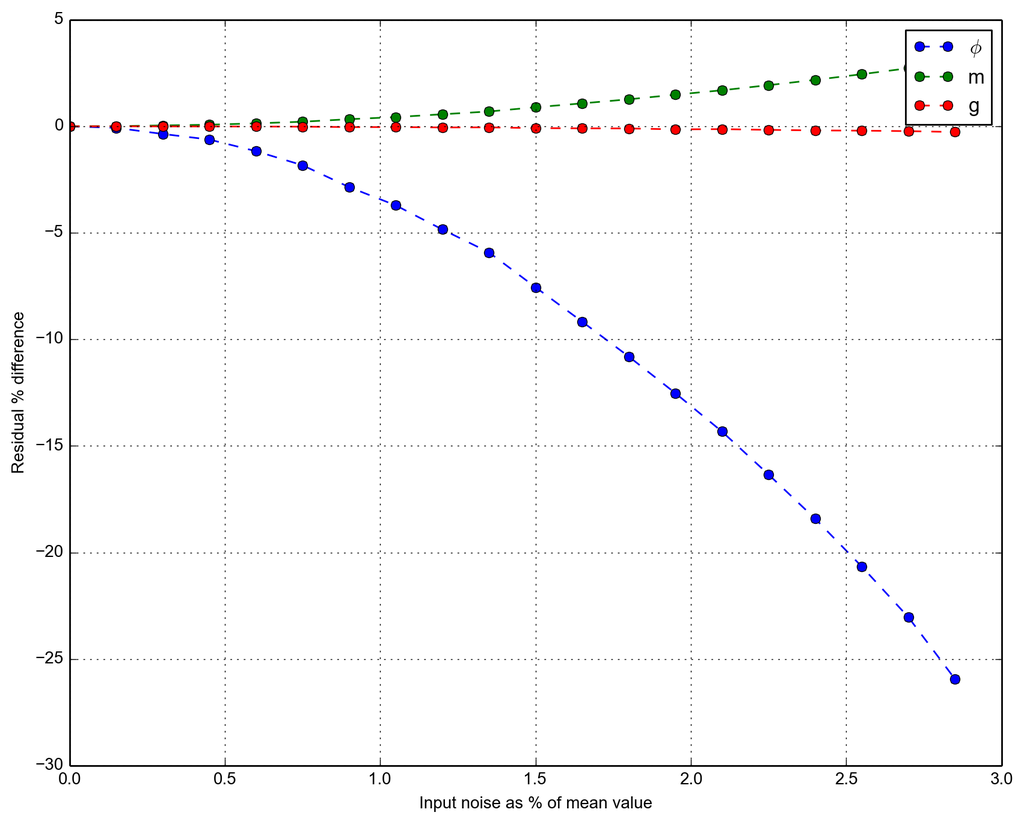

```python
noise_x = np.asarray(noise_list) * 100
res_y = np.asarray(residual_list)
p1 = pylab.plot(noise_x, res_y[:,0],'--o')
p2 = pylab.plot(noise_x, res_y[:,1],'--o')
#p3 = pylab.plot(noise_x, res_y[:,2],'--*')
p4 = pylab.plot(noise_x, res_y[:,3],'--o')
p = Rectangle((0, 0), 1, 1, fc="r")
pylab.legend(['$\phi$', 'm', 'g'])
pylab.ylabel('Residual % difference')
pylab.xlabel('Input noise as % of mean value')
pylab.grid()
pylab.show()
```

## Test 5

**Scaling:** We scale the input parameters artificially and see how well the model can invert the results.

```python
scale_vals = np.asarray([1.5, 3.0, 1.0, 1.0])
num_bootstraps = 1000000
min_noise = 0
max_noise = 0
noise_steps = 0.0015
param_str_list = ['p', 'm', 'd', 'g']
phi = scale_vals[0]
m = scale_vals[1]
d = scale_vals[2]
g = scale_vals[3]
x = None
residual = None
x_list = []
residual_list = []
noise_list = []

#for noise in np.arange(min_noise, max_noise, noise_steps):
#    noise_list.append(noise)
noise = 0.001 #.0001
x = run_bootstrap(a_phi, a_m, a_d, a_g, a_w, bb_phi, bb_m, bb_d, bb_g, bb_w, phi=phi, m=m, d=d, g=g, num_bootstraps=num_bootstraps, noise=noise)
residual = ((((x[0]) - scale_vals) / x[0]) * 100)

#print('number of loops = ' + str(max_noise / noise_steps))
print('=============================')
print('P :: value     :: residual %')
print('-----------------------------')
for i_iter, i in enumerate(x[0]):
    print('{0} :: {1:4f}  :: {2:4f} %' ).format(param_str_list[i_iter], i, residual[i_iter])
    #print(i)
print('=============================')
```

```
=============================
P :: value     :: residual %
-----------------------------
p :: 1.499578  :: -0.028165 %
m :: 3.000098  :: 0.003274 %
d :: 1.003066  :: 0.305623 %
g :: 0.999999  :: -0.000143 %
=============================
```

## Test 6

In this test we artificially scale the input vales over a range and see how well we can retrive the values over a range of different noise vlaues

```
Outer Loop :: 0.01
Outer Loop :: 0.12
Outer Loop :: 0.23
Outer Loop :: 0.34
Outer Loop :: 0.45
Outer Loop :: 0.56
Outer Loop :: 0.67
Outer Loop :: 0.78
Outer Loop :: 0.89
Outer Loop :: 1.0
Outer Loop :: 1.11
Outer Loop :: 1.22
Outer Loop :: 1.33
Outer Loop :: 1.44
Outer Loop :: 1.55
Outer Loop :: 1.66
Outer Loop :: 1.77
Outer Loop :: 1.88
Outer Loop :: 1.99
Covariance ::
[[  1.78296475e-02  -6.06368656e-05  -4.07827913e-06   8.22019627e-06]
 [ -6.06368656e-05   1.04471118e+00   2.45944181e-05  -8.39751095e-05]
 [ -4.07827913e-06   2.45944181e-05   7.13071186e-04  -2.01902392e-05]
 [  8.22019627e-06  -8.39751095e-05  -2.01902392e-05   4.27568305e-01]]
```

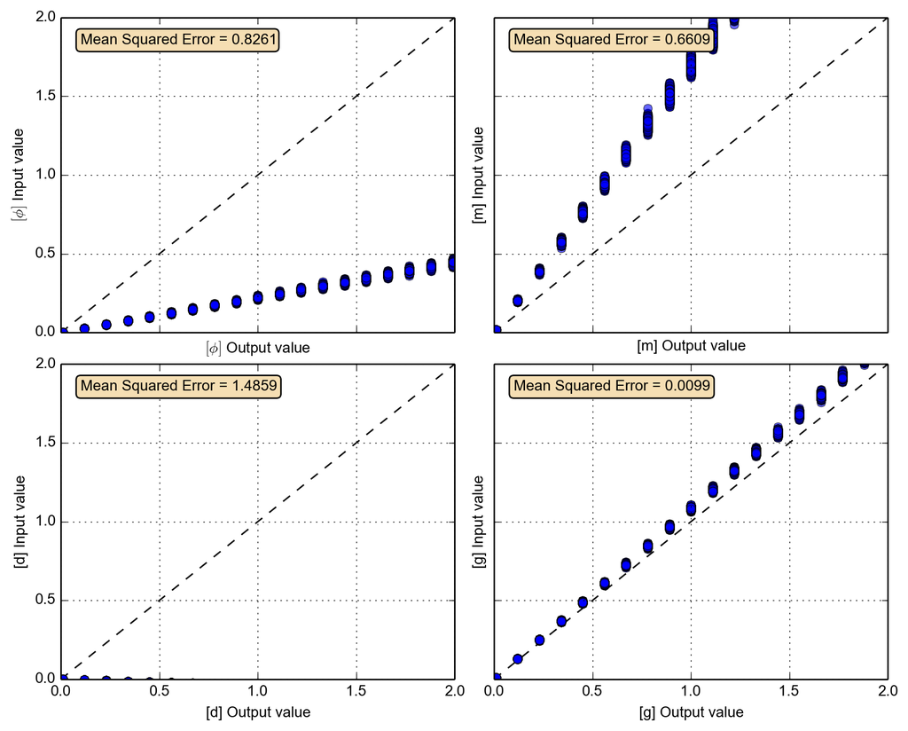

```python
pylab.rcParams['figure.figsize'] = (10.0, 8.0)
matplotlib.rcParams['savefig.dpi'] = 200
scale_vals = np.asarray([1.0, 1.0, 1.0, 1.0])
num_bootstraps = 1000
min_noise = 0
max_noise = 0.035
noise_steps = 0.0015
param_str_list = ['p', 'm', 'd', 'g']
x = None
residual = None
x_list = []
residual_list = []
noise_list = []
input_list = []
output_list = []


min_val = 0.01
max_val = 2.0
val_steps = 0.11

noise = 0.20 #.0001

for i_iter in np.arange(min_val, max_val, val_steps):
    print('Outer Loop :: ' + str(i_iter))
    for j_iter in np.arange(min_val, max_val, val_steps):
        for k_iter in np.arange(min_val, max_val, val_steps):
            for l_iter in np.arange(min_val, max_val, val_steps):
                x = run_bootstrap(a_phi, a_m, a_d, a_g, a_w, bb_phi, bb_m, bb_d, bb_g, bb_w, phi=i_iter, m=j_iter, d=k_iter, g=l_iter, num_bootstraps=num_bootstraps, noise=noise)
                input_list.append([i_iter, j_iter, k_iter, l_iter])
                output_list.append(x[0])

# Change lists to arrays
input_array = np.asarray(input_list)
output_array = np.asarray(output_list)

#===============
# Calculate the deviations
#===============
d_phi = np.mean(np.abs(output_array[:, 0] - input_array[:, 0])**2)
d_m = np.mean(np.abs(output_array[:, 1] - input_array[:, 1])**2)
d_d = np.mean(np.abs(output_array[:, 2] - input_array[:, 2])**2)
d_g = np.mean(np.abs(output_array[:, 3] - input_array[:, 3])**2)

#==========
# Setup the plots
#==========
props = dict(boxstyle='round', facecolor='wheat')

f, ((ax1, ax2), (ax3, ax4)) = pylab.subplots(2,2, sharex=True, sharey=True)
f.subplots_adjust(hspace=0.1)
f.subplots_adjust(wspace=0.1)

ax1.grid()
setp( ax1.get_xticklabels(), visible=False)
ax1.plot([0, 2], [0, 2], 'k--')
ax1.plot(np.asarray(input_list)[:, 0], np.asarray(output_list)[:,0], 'o', alpha=0.6)
ax1.text(0.05, 0.95, 'Mean Squared Error = %.4f'%(d_phi),
         transform=ax1.transAxes, fontsize=10, verticalalignment='top', bbox=props)
pylab.ylim(0, 2)
pylab.xlim(0, 2)
ax1.set_ylabel('$[\phi]$ Input value')
ax1.set_xlabel('$[\phi]$ Output value')

ax2 = pylab.subplot(2, 2, 2, sharey=ax1)
pylab.grid()
setp( ax2.get_xticklabels(), visible=False)
setp( ax2.get_yticklabels(), visible=False)
pylab.plot([0, 2], [0, 2], 'k--')
pylab.plot(np.asarray(input_list)[:, 1], np.asarray(output_list)[:,1], 'o', alpha=0.6)
ax2.text(0.05, 0.95, 'Mean Squared Error = %.4f'%(d_m),
         transform=ax2.transAxes, fontsize=10, verticalalignment='top', bbox=props)
pylab.ylim(0, 2)
pylab.xlim(0, 2)
ax2.set_ylabel('[m] Input value')
ax2.set_xlabel('[m] Output value')

ax3 = pylab.subplot(2, 2, 3)
pylab.plot([0, 2], [0, 2], 'k--')
pylab.grid()
pylab.plot(np.asarray(input_list)[:, 2], np.asarray(output_list)[:,2], 'o', alpha=0.6)
ax3.text(0.05, 0.95, 'Mean Squared Error = %.4f'%(d_d),
         transform=ax3.transAxes, fontsize=10, verticalalignment='top', bbox=props)
pylab.ylim(0, 2)
pylab.xlim(0, 2)

ax3.set_ylabel('[d] Input value')
ax3.set_xlabel('[d] Output value')

ax4 = pylab.subplot(2, 2, 4)
pylab.plot([0, 2], [0, 2], 'k--')
pylab.grid()
setp( ax4.get_yticklabels(), visible=False)
pylab.plot(np.asarray(input_list)[:, 3], np.asarray(output_list)[:,3], 'o', alpha=0.6)
ax4.text(0.05, 0.95, 'Mean Squared Error = %.4f'%(d_g),
         transform=ax4.transAxes, fontsize=10, verticalalignment='top', bbox=props)
pylab.ylim(0, 2)
pylab.xlim(0, 2)

ax4.set_ylabel('[g] Input value')
ax4.set_xlabel('[g] Output value')

#f.savefig(str(noise) + ' _NoiseTest.png')

#=========
# Calculate the covariance matrix
#=========
covar = np.cov(np.asarray([output_array[:, 0].T, output_array[:, 1].T,output_array[:, 2].T,output_array[:, 3].T]))
print('Covariance :: ')
print(covar)
np.savetxt(str(noise) + '_NoiseTest.csv', covar)
```

```
0.0  noise
```

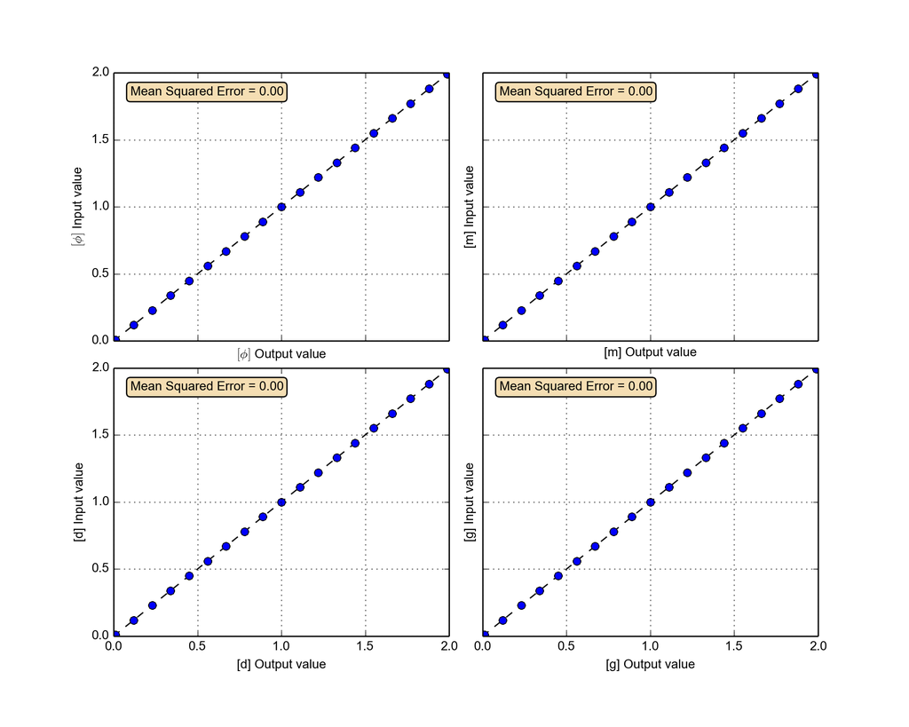

```
Covariance Matrix
[[  3.63002803e-01   2.27680381e-08   1.10128676e-09  -1.51214472e-08]
 [  2.27680381e-08   3.63002785e-01  -1.02391196e-09   1.88197755e-09]
 [  1.10128676e-09  -1.02391196e-09   3.63002787e-01   1.97676779e-09]
 [ -1.51214472e-08   1.88197755e-09   1.97676779e-09   3.63002785e-01]]
0.01  noise
```

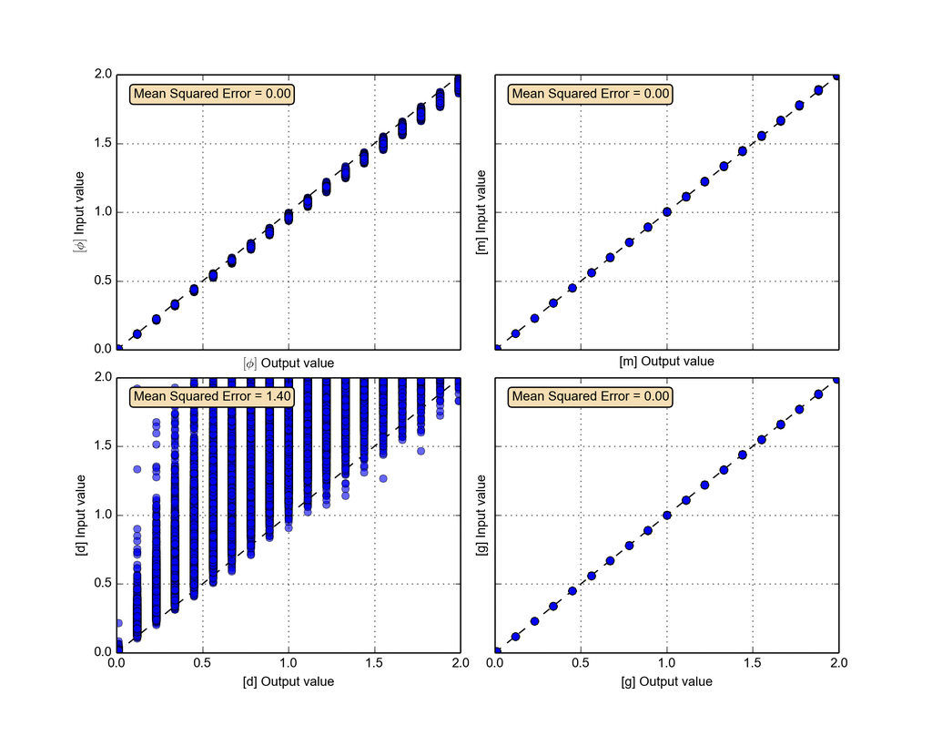

```
Covariance Matrix
[[  3.40089109e-01  -4.04189281e-05  -3.55329584e-03  -1.52740144e-05]
 [ -4.04189281e-05   3.65895321e-01   1.50988839e-03  -2.70822606e-07]
 [ -3.55329584e-03   1.50988839e-03   1.71934774e+00   1.53984618e-03]
 [ -1.52740144e-05  -2.70822606e-07   1.53984618e-03   3.62743964e-01]]
0.02  noise
```

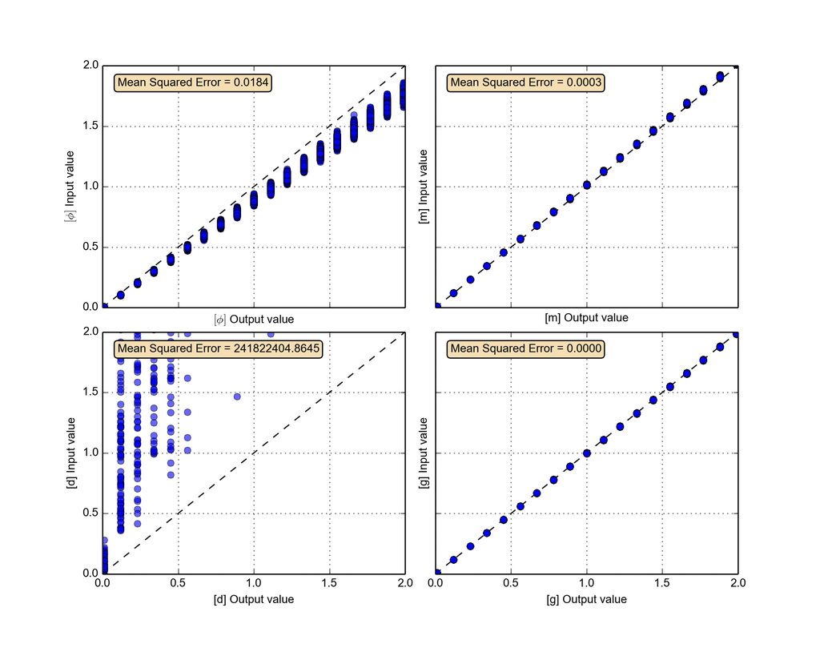

```
Covariance Matrix
[[  2.84416996e-01  -4.59241535e-05  -8.40326539e+00   5.46841899e-05]
 [ -4.59241535e-05   3.74470894e-01  -8.58692035e+00  -7.88004665e-06]
 [ -8.40326539e+00  -8.58692035e+00   2.41822318e+08  -2.31414243e+01]
 [  5.46841899e-05  -7.88004665e-06  -2.31414243e+01   3.62028255e-01]]
0.03  noise
```

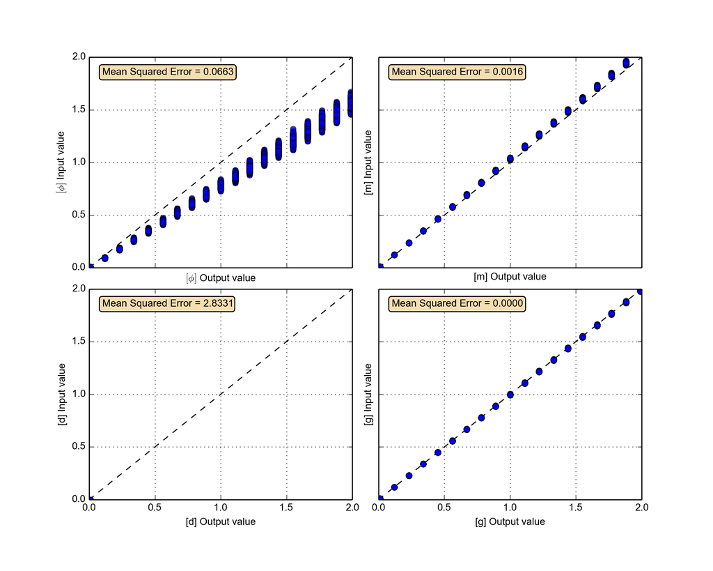

```
Covariance Matrix
[[  2.21211239e-01  -3.30462630e-05  -1.17641454e-03   4.90005239e-06]
 [ -3.30462630e-05   3.88514259e-01   2.95779962e-05   2.03746872e-06]
 [ -1.17641454e-03   2.95779962e-05   7.92224341e-02  -2.09840613e-04]
 [  4.90005239e-06   2.03746872e-06  -2.09840613e-04   3.61027136e-01]]
0.04  noise
```

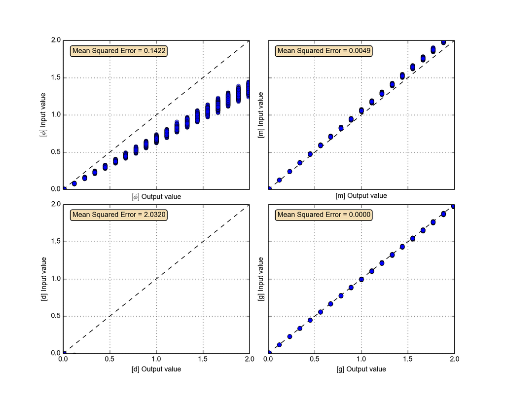

```
Covariance Matrix
[[  1.66858726e-01  -1.15387566e-04  -3.13344569e-04   2.13470719e-05]
 [ -1.15387566e-04   4.07669958e-01   1.46211952e-04  -1.05327461e-05]
 [ -3.13344569e-04   1.46211952e-04   1.85746805e-02  -7.50848792e-05]
 [  2.13470719e-05  -1.05327461e-05  -7.50848792e-05   3.59949510e-01]]
0.05  noise
```

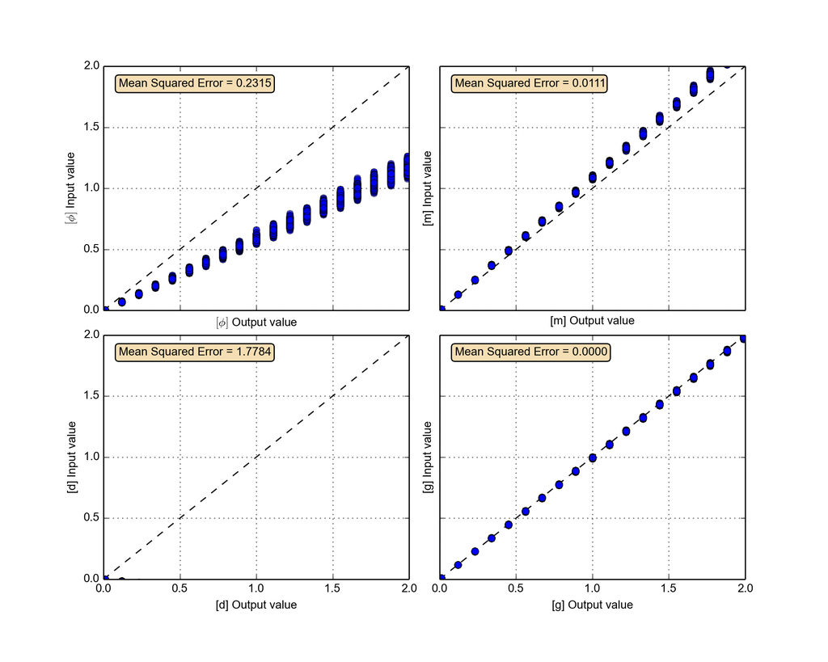

```
Covariance Matrix
[[  1.25795281e-01  -8.30348811e-05  -8.08630810e-05   4.00999517e-05]
 [ -8.30348811e-05   4.31406064e-01   5.93701465e-05  -2.21176677e-05]
 [ -8.08630810e-05   5.93701465e-05   7.55161866e-03   5.07588899e-07]
 [  4.00999517e-05  -2.21176677e-05   5.07588899e-07   3.59039048e-01]]
0.06  noise
```

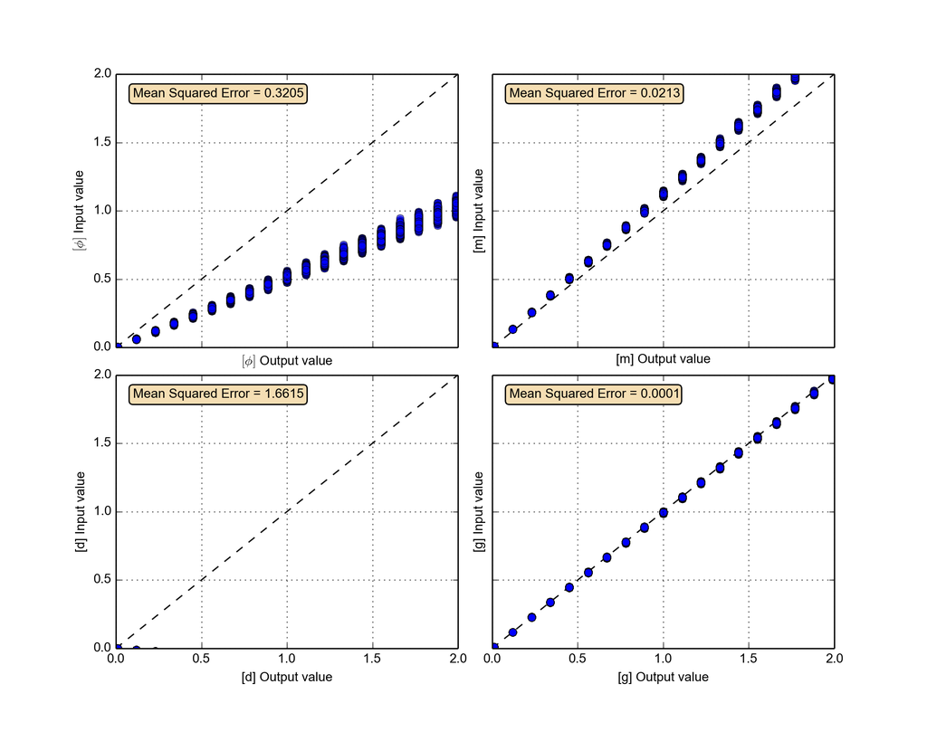

```
Covariance Matrix
[[  9.65532809e-02  -7.84007874e-05  -5.16498058e-05  -1.24850637e-05]
 [ -7.84007874e-05   4.59273512e-01   5.29050767e-05   3.95046840e-06]
 [ -5.16498058e-05   5.29050767e-05   4.00493886e-03  -3.60605873e-07]
 [ -1.24850637e-05   3.95046840e-06  -3.60605873e-07   3.58521347e-01]]
0.08  noise
```

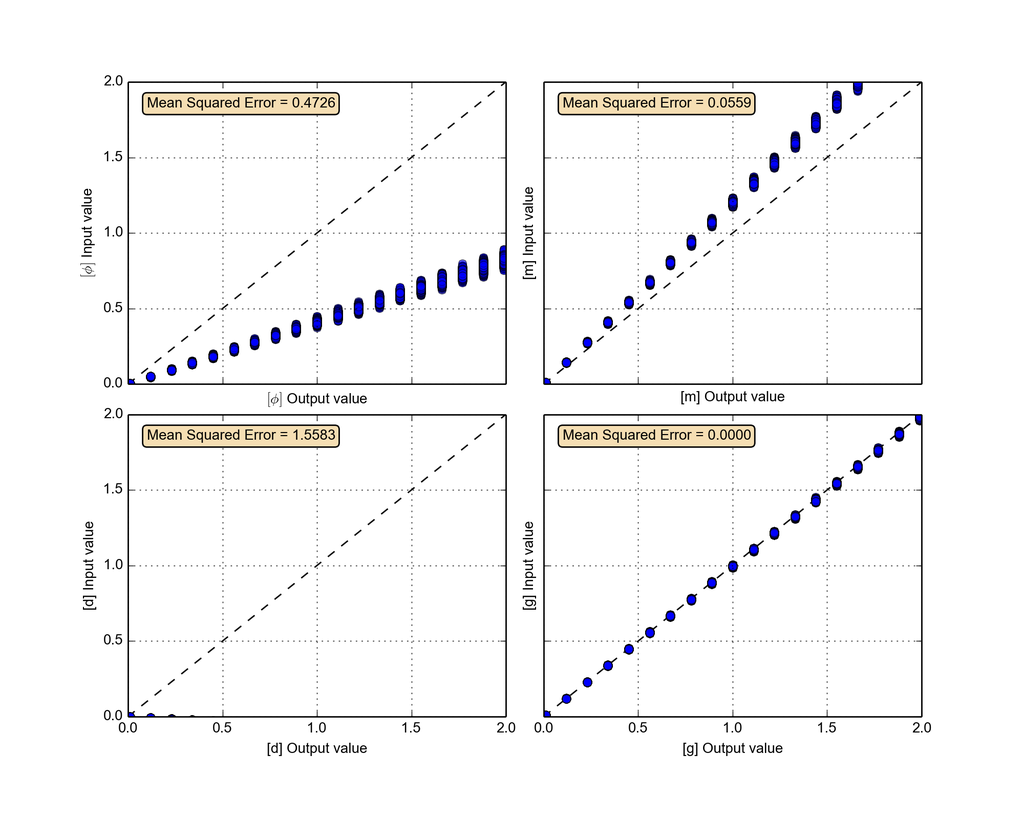

```
Covariance Matrix
[[  6.14993800e-02  -8.61911002e-05  -2.54810352e-05   2.51016667e-06]
 [ -8.61911002e-05   5.24876752e-01   4.14990846e-05  -3.30934102e-06]
 [ -2.54810352e-05   4.14990846e-05   1.76422954e-03  -9.40954673e-06]
 [  2.51016667e-06  -3.30934102e-06  -9.40954673e-06   3.59299341e-01]]
0.1  noise
```

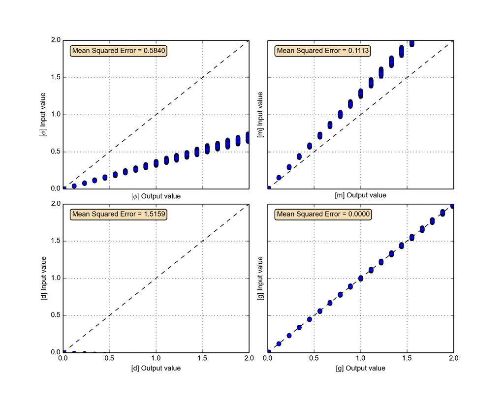

```
Covariance Matrix
[[  4.33948560e-02  -6.90571556e-05  -1.26875969e-05   2.10861134e-05]
 [ -6.90571556e-05   6.00091530e-01   2.72665551e-05  -3.18924924e-05]
 [ -1.26875969e-05   2.72665551e-05   1.09216181e-03  -1.49507469e-05]
 [  2.10861134e-05  -3.18924924e-05  -1.49507469e-05   3.63007197e-01]]
0.2  noise
```

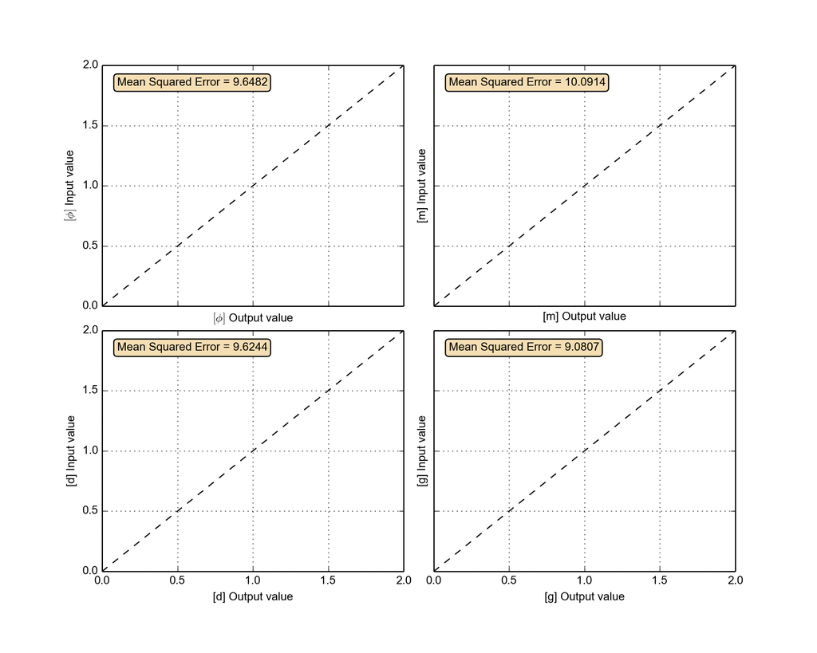

```
Covariance Matrix
[[ 0.02725647 -0.00924926 -0.00777624 -0.0084078 ]
 [-0.00924926  0.0299638  -0.00912666 -0.00963339]
 [-0.00777624 -0.00912666  0.02716561 -0.00857925]
 [-0.0084078  -0.00963339 -0.00857925  0.02481906]]
```

```python
#==========
# Load all the previous runs
#==========
import os
import sympy as sym
sym.init_printing(use_unicode=True)

cvar = sym.symbols('cvar')
files = os.listdir(".")
files.sort()


#print(files)
from IPython.core.display import Image
for f in files:
    if '.png' in f:
        print(f.split('_')[0] + ' noise')
        p = Image(filename=f)
        display(p)
        noise_pct = f.split('_')[0].split(' ')[0]
        #print(noise_pct)
        f2 = open(noise_pct+'_NoiseTest.csv','r')
        cvar = np.loadtxt(f2)
        print('Covariance Matrix')
        print(cvar)
```

# Inversion from ACS data

```python
import pandas as pd
siops = pd.read_csv('Ligurian Sea SIOP spectra.csv')
#siops['wavelength']
```

## SIOPs from Ligurian Sea

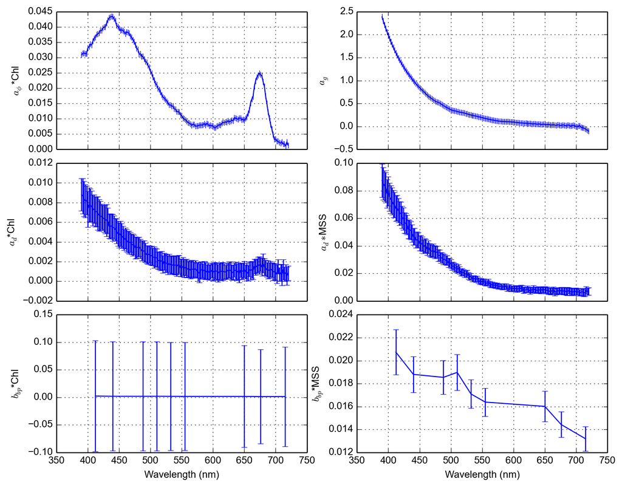

```python
pylab.rcParams['figure.figsize'] = (10.0, 8.0)
matplotlib.rcParams['savefig.dpi'] = 200
wavelength = siops['wavelength']

f, ((ax1, ax2), (ax3, ax4), (ax5, ax6)) = pylab.subplots(3,2, sharex='all')
f.subplots_adjust(hspace=0.1)
#f.subplots_adjust(wspace=0.2)

#==========
# Set up the plots
#==========

ax1.errorbar(wavelength, siops['aph*Chl'], xerr=siops['95%CI.1'])
ax1.set_ylabel('$a_\phi$*Chl')
ax1.grid()
setp( ax1.get_xticklabels(), visible=False)

ax2.errorbar(wavelength, siops['a*CDOM'], xerr=siops['95%CI'])
ax2.set_ylabel('$a_{g}$')
setp( ax2.get_xticklabels(), visible=False)
ax2.grid()

ax3.errorbar(siops['wavelength.1'], siops['adet*Chl'], siops['95%CI.2'])
ax3.set_ylabel('$a_{d}$*Chl')
setp( ax3.get_xticklabels(), visible=False)
ax3.grid()

ax4.errorbar(siops['wavelength.2'], siops['adet*MSS'], siops['95%CI.3'])
ax4.set_ylabel('$a_{d}*$MSS')
setp( ax4.get_xticklabels(), visible=False)
ax4.grid()
#ax5.errorbar(siops['wavelength.3'], siops['bp*Chl'], siops['95%CI.4'])
#ax6.errorbar(siops['wavelength.4'], siops['bp*MSS'], siops['95%CI.5'])
ax5.errorbar(siops['wavelength.5'], siops['bbp*Chl'], siops['95%CI.5'])
ax5.set_ylabel('$b_{bp}$*Chl')
ax5.set_xlabel('Wavelength (nm)')
ax5.grid()

ax6.errorbar(siops['wavelength.5'], siops['bbp*MSS'], siops['95%CI.6'])
ax6.set_ylabel('$b_{bp}$*MSS')
ax6.set_xlabel('Wavelength (nm)')
ax6.grid()
```

## Characterising the noise

One approach could be as follows:

- Let $\Delta$ be the uncertainty on the measurement value at all the wavelengths, where the uncertainty is defined as 95% confidence interval.
- Let $\eta$ be the noise
- The the general model of n constituents is

$0 = \sum\limits_{i=1}^n\left[a_i(\lambda)\left[ \frac{b_b}{a}\right](\lambda) - b_{bi}(\lambda) \right].x_i + a_w(\lambda)\left[\frac{b_b}{a}\right](\lambda) - b_{bw} $

Let

- $s_1 = \frac{b_b}{a}$
- $s_2 = a_i [s_1] - b_{bi}$
- $s_3 = a_w[s_1] - b_{bw}$

then

- $\Delta s_1 = \frac{\Delta b_b}{b_b} + \frac{\Delta a}{a}$
- $\Delta s_2 = \frac{\Delta a_i}{a_i} + \frac{\Delta s_1}{s_1} + \Delta b_{bi}$
- $\Delta s_3 = \frac{\Delta a_w}{a_w} + \frac{\Delta s_1}{s_1} + \Delta_{bw}$

$\Delta \eta = \frac{\Delta s_2}{s_2} + \frac{\Delta s_3}{s_3}$

## Noise distribution

The noise is then estimated to be a normal distribution. $\Delta$ was previously defined as 95% confidence interval which is ~$2\sigma$ standard deviations of a normal distribution. Therefore the noise is estimated as

$\epsilon = \frac{1}{\frac{\Delta \eta}{2}\sqrt{2 \pi }} e^{-\frac{(x - \mu)^2}{\Delta \eta^2}}$

There are some caveats:

- As $\phi, m, d, g$ are solved simultaneously, it can be defficult to define $\Delta$ for $x_i$ above. One approach could be to assume guassian noise on the IOPs and propate that through the model on the first pass. Repeat this for a large training set of data and use the covariance matrix from the model outputs to estimate the noise on $x_i$. Make a second pass on the model with a new $\Delta x_i$ defined from the covariance matrix.
- Assuming the noise fits a guassian distibution is an assumption and may or may not be correct. Further investigation in to the distribution of noise needs to be conducted.

## Optical deconvolution of ACS measurements

The following shows an attempt to use the bootstrap method to deconvolve the optical conststituents from ACS data obtained from Ligurian Sea March 2009.

### Data file

The data used for the following test was made available by David McKee and contains the following data:

- Station ID
- Chl-a
- Average Suspended Particulate Matter (SPM)
- bbp(440)
- CDOM(440)
- Depth
- Absroption (412 - 715)nm measured with an AC-9
- Scattering absroption (412 - 715)nm measured with an AC-9

### Modelling the noise

Modelling the noise is difficult as very little data that descrbes the noise is available.

#### Assumptions

- The noise is Gaussian
- The noise applied to the SIOPs is uncorrelated
- Each wavelength is an uncorrelated measurement with respect to other wavelengths
- Scattering fraction of b / bb is 0.2

#### Method

- The SIOP data described in 'Ligurian Sea SIOP spectra.csv' was interpolated to the ACS spectral resolution.
- The SIOPS were normalised to 440 nm for the absorption terms and 555 nm for the scattering terms.
- For each SIOP the measured uncertainty at each wavelength is taken to be 2 standard deviations of Gaussian noise for that measurement. The simulted measurement noise ($\eta$) is applied to each SIOP. That is to say

$0 = \sum\limits_{i=1}^n\left[ \left\{a_i(\lambda) + \eta_{ai}\right\}(\lambda)\left[ \frac{b_b}{a}\right](\lambda) - \left\{b_{bi}(\lambda) + \eta_{bi}(\lambda) \right\} \right].x_i + a_w(\lambda)\left[\frac{b_b}{a}\right](\lambda) - b_{bw} $

- The measurements are replecated for each bootstrap, the noise regenerated and applied
- $[\phi, m, d, g]$ are solved by using least-squares regression
- The measured Chl-a described in the in-situ measurements were converted to $a_\phi(440)$ using the relation $a_\phi(440) = a[Chl]^b$ (Bricaud et. al., 1995) where a and b are usually emperically derived constants specific to the area of interest. In this case initial values used were 0.05 and 0.626 for $a$ and $b$ respectively and the value of $a$ was varied until a value of 0.09 showed closest agreement with modelled results.

### Results

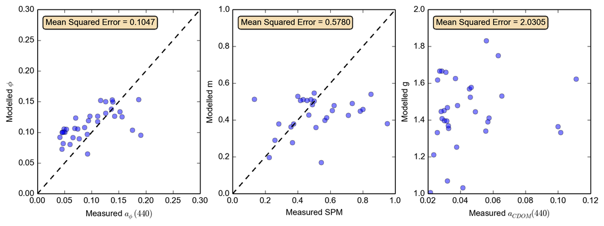

```python
import scipy
scattering_fraction = 0.2
num_bootstraps = 4000
scale_noise = 1 # 1 == no scalling.
measurement_number = 0
x_list = [] # list for storing outputs for plotting later
num_insitu_mesurements = 34

#==========
# Read in Ligurian sea data file
#==========
acs_data = pd.read_csv('Ligurian_Constits_IOPS.csv')

#==========
# Redfine our IOPs
#==========

# Interpolate all values to the ACS wavelengths
wavelength  = np.asarray([412, 440, 488, 510, 532, 555, 650, 676, 715])
a_phi = scipy.interp(wavelength,np.asarray(siops['wavelength']), np.asarray(siops['aph*Chl']))
a_d = scipy.interp(wavelength,np.asarray(siops['wavelength']), np.asarray(siops['adet*Chl']))
a_m = scipy.interp(wavelength,np.asarray(siops['wavelength']), np.asarray(siops['adet*MSS']))
a_g = scipy.interp(wavelength,np.asarray(siops['wavelength']), np.asarray(siops['a*CDOM']))

# Uncertainties for each waveslength of each IOP
da_phi = scipy.interp(wavelength,np.asarray(siops['wavelength']), np.asarray(siops['95%CI.1']))
da_d = scipy.interp(wavelength,np.asarray(siops['wavelength']), np.asarray(siops['95%CI.2']))
da_m = scipy.interp(wavelength,np.asarray(siops['wavelength']), np.asarray(siops['95%CI.3']))
da_g = scipy.interp(wavelength,np.asarray(siops['wavelength']), np.asarray(siops['95%CI']))

db_phi =  np.asarray(siops['95%CI.5'])[0:9] # scipy.interp(wavelength,np.asarray(siops['wavelength']), np.asarray(siops['95%CI.5']))
db_m = np.asarray(siops['95%CI.6'])[0:9] # scipy.interp(wavelength,np.asarray(siops['wavelength']), np.asarray(siops['95%CI.6']))

a_w = np.asarray([0.00469, 0.00635, 0.01454, 0.0325, 0.0442, 0.0592, 0.34, 0.4546, 1.029])
bb_phi = np.asarray(siops['bbp*Chl'])[0:9]# scipy.interp(wavelength,np.asarray(siops['wavelength']), np.asarray(siops['bbp*Chl'])) # check thses
bb_m = np.asarray(siops['bbp*MSS'])[0:9] #scipy.interp(wavelength,np.asarray(siops['wavelength.4']), np.asarray(siops['bbp*MSS']))
bb_g = np.asarray([0, 0, 0, 0, 0, 0, 0, 0, 0])
bb_d = np.asarray([0, 0, 0, 0, 0, 0, 0, 0, 0])
bb_w = np.asarray([0.00333, 0.00245, 0.00158, 0.0013, 0.00109, 0.000925, 0.0005, 0.00037, 0.000325])

#==========
# Normalise the values at 440 for a and 550 for b
#==========
idx_440 = np.where(wavelength==440)
idx_555 = np.where(wavelength==555)

a_phi = a_phi / a_phi[idx_440]
da_phi = da_phi / da_phi[idx_440]

bb_m = bb_m / bb_m[idx_555]
#y=0.5
#bb_m = bb_m[idx_555]*(555/wavelength)**y

a_g = a_g / a_g[idx_440]

#==========
# Loop through the measurements
#==========
for measurement_number in range(0, num_insitu_mesurements): # there are 33 measurements but should remove hardcoded values later
    a = np.asarray(acs_data.ix[measurement_number][7:16])
    bb = np.asarray(acs_data.ix[measurement_number][16:25] * scattering_fraction)

    #==========
    # The model
    #==========
    rand_size = da_phi.shape[0]
    Aa = np.zeros((wavelength.shape[0], 4))
    a_noise_vec = np.zeros_like(Aa)

    Aa[:, 0] = a_phi.T #+ (da_phi * scipy.randn(rand_size).T)
    Aa[:, 1] = a_m.T #+ (da_m * scipy.randn(rand_size).T)
    Aa[:, 2] = a_d.T #+ (da_d* scipy.randn(rand_size).T)
    Aa[:, 3] = a_g.T #+ (da_g * scipy.randn(rand_size).T)

    Ab = np.zeros((wavelength.shape[0], 4))
    b_noise_vec = np.zeros_like(Ab)
    Ab[:, 0] = bb_phi.T #+ (db_phi * scipy.randn(rand_size).T)
    Ab[:, 1] = bb_m.T #+ (db_m * scipy.randn(rand_size).T)
    Ab[:, 2] = bb_d.T #+ (db_d * scipy.randn(rand_size).T)
    Ab[:, 3] = bb_g.T #+ (db_g * scipy.randn(rand_size).T)

    A = np.zeros((Aa.shape[0] * num_bootstraps, Aa.shape[1]))
    bb_over_a = None

    bb_over_a = (bb / a)

    #--------------------------------------------------#
    # Now we replicate the matricies and add the noise -- the slow way
    #--------------------------------------------------#
    for j_iter in range(num_bootstraps):
        a_noise_vec[:, 0] = da_phi * scipy.randn(rand_size).T
        a_noise_vec[:, 1] = da_m * scipy.randn(rand_size).T
        a_noise_vec[:, 2] = da_d * scipy.randn(rand_size).T
        a_noise_vec[:, 3] = da_g * scipy.randn(rand_size).T

        a_noise_vec *= scale_noise

        b_noise_vec[:, 0] = db_phi * scipy.randn(rand_size).T
        b_noise_vec[:, 1] = db_m * scipy.randn(rand_size).T
        b_noise_vec[:, 2] = np.zeros_like(db_m)
        b_noise_vec[:, 3] = np.zeros_like(db_m)

        b_noise_vec *= scale_noise

        for i_iter in range(Aa.shape[1]):
            A[j_iter * wavelength.shape[0] : wavelength.shape[0] + j_iter * wavelength.shape[0], i_iter] = ((Aa[:, i_iter] + a_noise_vec[:, i_iter]) * (bb_over_a[:]) - (Ab[:, i_iter] + b_noise_vec[:, i_iter])) #* scale[i_iter]


    b = (scipy.squeeze(a_w.T) * bb_over_a - scipy.squeeze(bb_w.T)) * - 1
    b = scipy.tile(b, (num_bootstraps))

    x = scipy.sparse.linalg.lsqr(A, b.T)
    x_list.append(x[0])

#==========
# Plot measured vs inverted
#==========
pylab.rcParams['figure.figsize'] = (12, 4)
matplotlib.rcParams['savefig.dpi'] = 200
wavelength = siops['wavelength']
props = dict(boxstyle='round', facecolor='wheat', alpha=0.5)

f, (ax1, ax2, ax3) = pylab.subplots(1,3)  # subplot_kw=dict(aspect='equal')
#f.subplots_adjust(hspace=0.1)

#==========
# a_phi(440) ~ a*[Chl]**b
#==========
a = 0.09
b = 0.626

x_array = np.asarray(x_list)

#==========
# Find the Mean Squared Error
#==========
mse_phi = np.mean(a*np.abs(acs_data['Chl-a 1']**b - x_array[:, 0])**2)
mse_m = np.mean(np.abs(acs_data['AveSPM'] - x_array[:, 1])**2)
mse_g = np.mean(np.abs(acs_data['aCDOM_440'] - x_array[:, 3])**2)

for i_iter in range(0, num_insitu_mesurements):
    iop = acs_data.ix[i_iter][1:5]
    ax1.plot(a*iop[0]**b, x_list[i_iter][0], 'bo', alpha=0.5)
    ax1.plot([0, 0.3],[0, 0.3], 'k--')
    ax1.set_xlabel('Measured $a_\phi(440)$')
    ax1.set_ylabel('Modelled $\phi$')
    ax1.text(0.05, 0.95, 'Mean Squared Error = %.4f'%(mse_phi),
         transform=ax1.transAxes, fontsize=10, verticalalignment='top', bbox=props)


    ax2.plot(iop[2], x_list[i_iter][1], 'bo', alpha=0.5)
    ax2.set_xlabel('Measured SPM')
    ax2.set_ylabel('Modelled m')
    ax2.plot([0, 1],[0, 1], 'k--')
    ax2.set_ylim([0, 1])
    ax2.set_xlim([0, 1])
    ax2.text(0.05, 0.95, 'Mean Squared Error = %.4f'%(mse_m),
         transform=ax2.transAxes, fontsize=10, verticalalignment='top', bbox=props)

    #ax3.plot(iop[2], x_list[i_iter][2], 'ko', alpha=0.5)
    #ax2.set_ylabel('Measured $b_{bp}(440)$')
    #ax2.set_xlabel('Modelled m')

    ax3.plot(iop[3], x_list[i_iter][3], 'bo', alpha=0.5)
    ax3.set_xlabel('Measured $a_{CDOM}(440)$')
    ax3.set_ylabel('Modelled g')
    ax3.text(0.05, 0.95, 'Mean Squared Error = %.4f'%(mse_g),
         transform=ax3.transAxes, fontsize=10, verticalalignment='top', bbox=props)
```

## Conclusions

- $a_d$ and $a_g$ are not linearly seperable and therefore cannot be solved using the bootstrap method.
- Applying the bootstrap method to radiometry is a step too far at this point in time
- Comparing $a_{\phi}$(440) with Chl-a is difficult and the values of $a$ and $b$ should be tuned using in-situ measurements rather than making the model fit the inversion.
- $b_{bp}$ SIOP profile doesn't look correct. It does not fit the familiar $b_{bm} = b_{bm}(555)(\frac{555}{\lambda})^y$
- The relative uncertainty on the scattering SIOPs is very large.
- In the simulated test, increasing the noise increased the residual faster than it increased the variance.